# regression models w mice imputation

## Now going back to the imputed_data

# Examine strip plot

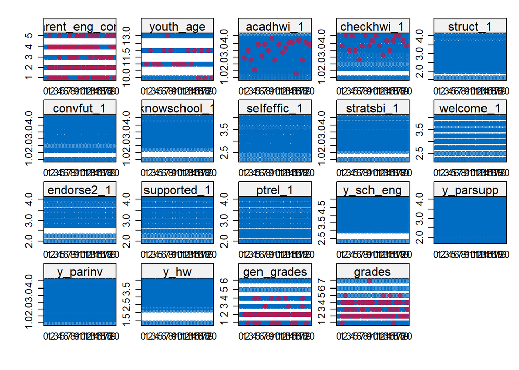

```r
stripplot(imputed_data, pch = 20, cex = 1.2) # Red dots are imputed values, blue are observed values
```

# Examine kernel density plot

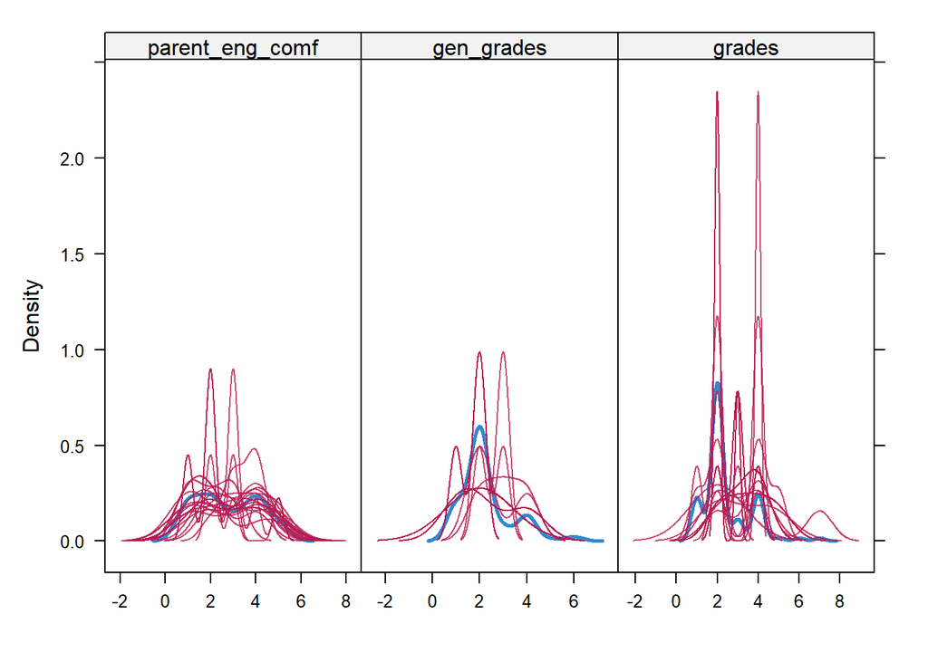

```r
densityplot(imputed_data, scales = list(x = list(relation = "free")), layout = c(3, 1)) # Red lines are imputed value distributions, blue are observed value distributions
```

standarizing variables - start

# Step 1: Convert to long format for processing

```r
imputed_long <- complete(imputed_data, action = "long", include = TRUE)

imputed_long <- imputed_long %>%
  mutate(youth_gender = as.numeric(youth_gender))

colnames(imputed_long)
```

```
##  [1] "parent_eng_comf" "youth_age"       "youth_gender"    "acadhwi_1"
##  [5] "checkhwi_1"      "struct_1"        "convfut_1"       "knowschool_1"
##  [9] "selfeffic_1"     "stratsbi_1"      "welcome_1"       "endorse2_1"
## [13] "supported_1"     "ptrel_1"         "y_sch_eng"       "y_parsupp"
## [17] "y_parinv"        "y_hw"            "gen_grades"      "grades"
## [21] ".imp"            ".id"
```

# Step 2: Function to standardize within each imputed dataset

```r
standardize <- function(df) {
  df <- df %>%
    mutate(across(c(selfeffic_1, y_sch_eng, y_parsupp, y_parinv, y_hw, gen_grades, grades, parent_eng_comf, youth_age, acadhwi_1, checkhwi_1, struct_1, convfut_1, knowschool_1, stratsbi_1, welcome_1, endorse2_1, supported_1, ptrel_1), ~ scale(.)[,1]))  # Standardizing variables
  return(df)
} # STANDARDIZING ALL EXCEPT GENDER THAT IS A FACTOR
```

# Step 3: Apply standardization within each imputed dataset

```r
imputed_long <- imputed_long %>%
  group_by(.imp) %>%
  group_modify(~ standardize(.x))

imputed_long <- imputed_long %>%
  mutate(youth_gender = factor(youth_gender),
         youth_gender = relevel(youth_gender, ref = "1")) # male
```

# Step 4: Convert back to `mids` object

```r
imputed_data_std <- as.mids(as.data.frame(imputed_long))
```

standarizing variables - end

These models responded the changes I made on the PTIQ endorse (called here endorse2) and p-t relationship scales and the school involvement scale knowschool_1, stratsbi_1).

knowschool is school familiarity in paper stratsbi is strategic school inv welcome is belonging

# Step 5: Run regression on standardized data

# Step 6: Pool the results to get standardized betas

# Multiple regression, outcome: y_sch_eng (standardized)

```r
# without support
fit1_st <- with(imputed_data_std, lm(y_sch_eng ~ parent_eng_comf + youth_age + youth_gender + acadhwi_1 + checkhwi_1 + struct_1 + knowschool_1 + stratsbi_1 + welcome_1 + endorse2_1 + ptrel_1))

est1_st <- pool(fit1_st)
summary(est1_st)
```

```
##               term    estimate std.error  statistic       df     p.value
## 1      (Intercept) -0.16480949 0.1378350 -1.1957009 80.05026 0.235343280
## 2  parent_eng_comf -0.03764862 0.1035172 -0.3636944 78.38180 0.717065382
## 3        youth_age  0.05575236 0.1029900  0.5413375 79.61071 0.589786710
## 4    youth_gender2  0.34669497 0.2044931  1.6953870 80.01165 0.093890438
## 5        acadhwi_1  0.04933598 0.1211550  0.4072139 79.25708 0.684948654
## 6       checkhwi_1  0.28468895 0.1072819  2.6536530 79.81494 0.009606055
## 7         struct_1  0.12223024 0.1543536  0.7918845 80.03802 0.430768707
## 8     knowschool_1  0.03048249 0.1414956  0.2154307 79.98564 0.829979962
## 9       stratsbi_1  0.13351283 0.1285451  1.0386459 79.90665 0.302102178
## 10       welcome_1  0.19394991 0.1648233  1.1767142 80.05588 0.242796566
## 11      endorse2_1 -0.12009200 0.1688474 -0.7112458 80.04820 0.478999401
## 12         ptrel_1 -0.28334519 0.1317115 -2.1512556 80.02222 0.034472119
```

```r
pool.r.squared(fit1_st) # 0.22
```

```
##           est      lo 95     hi 95         fmi
## R^2 0.2184541 0.08544787 0.3747314 0.001626616
```

# Step 5: Run regression on standardized data

# Step 6: Pool the results to get standardized betas

# Multiple regression, outcome: grades (youth report) (standardized)

```r
# without support
fit2_st <- with(imputed_data_std, lm(grades ~ parent_eng_comf + youth_age + youth_gender + acadhwi_1 + checkhwi_1 + struct_1 + knowschool_1 + stratsbi_1 + welcome_1 + endorse2_1 +  ptrel_1))

est2_st <- pool(fit2_st)
summary(est2_st)
```

```
##               term     estimate std.error   statistic       df    p.value
## 1      (Intercept)  0.278612291 0.1543002  1.80565043 70.83771 0.07522168
## 2  parent_eng_comf  0.068630545 0.1140114  0.60196205 72.29688 0.54908261
## 3        youth_age  0.005323793 0.1106409  0.04811779 78.73272 0.96174422
## 4    youth_gender2 -0.535618425 0.2237514 -2.39381077 75.69450 0.01915134
## 5        acadhwi_1 -0.020279739 0.1332667 -0.15217414 73.63533 0.87946578
## 6       checkhwi_1 -0.107351721 0.1151245 -0.93248394 79.13777 0.35392273
## 7         struct_1 -0.154782461 0.1673249 -0.92504159 77.55245 0.35781381
## 8     knowschool_1  0.127703207 0.1519880  0.84021876 79.16563 0.40331620
## 9       stratsbi_1  0.033894622 0.1394823  0.24300296 77.21133 0.80864751
## 10       welcome_1  0.072139925 0.1771543  0.40721521 79.12554 0.68494948
## 11      endorse2_1 -0.130756942 0.1856099 -0.70447169 74.77733 0.48332737
## 12         ptrel_1  0.035430383 0.1481431  0.23916316 69.74117 0.81168051
```

```r
pool.r.squared(fit2_st) # 0.11
```

```
##           est      lo 95     hi 95        fmi
## R^2 0.1113135 0.01925908 0.2536383 0.01706447
```

# Step 5: Run regression on standardized data

# Step 6: Pool the results to get standardized betas

# Multiple regression, outcome: hw best practices (standardized)

```r
# without support
fit3_st <- with(imputed_data_std, lm(y_hw ~ parent_eng_comf + youth_age + youth_gender + acadhwi_1 + checkhwi_1 + struct_1 + knowschool_1 + stratsbi_1 + welcome_1 + endorse2_1 +  ptrel_1))

est3_st <- pool(fit3_st)
summary(est3_st) # no predictors were significantly related with the outcome
```

```
##               term     estimate std.error   statistic       df   p.value
## 1      (Intercept)  0.002719536 0.1460747  0.01861743 79.81080 0.9851928
## 2  parent_eng_comf  0.111565495 0.1113779  1.00168422 75.14928 0.3197107
## 3        youth_age  0.006316210 0.1097840  0.05753309 78.33906 0.9542670
## 4    youth_gender2 -0.007204532 0.2166649 -0.03325196 79.81235 0.9735567
## 5        acadhwi_1  0.073695578 0.1309632  0.56271966 75.20940 0.5752994
## 6       checkhwi_1  0.126573155 0.1144829  1.10560746 78.36291 0.2722793
## 7         struct_1 -0.050179892 0.1638086 -0.30633242 79.56608 0.7601517
## 8     knowschool_1  0.179768471 0.1498622  1.19955842 79.84679 0.2338583
## 9       stratsbi_1  0.037308595 0.1363155  0.27369294 79.56076 0.7850299
## 10       welcome_1 -0.092682864 0.1745120 -0.53109741 79.96971 0.5968233
## 11      endorse2_1  0.186316025 0.1787178  1.04251530 80.01190 0.3003126
## 12         ptrel_1 -0.034130410 0.1394346 -0.24477711 79.95869 0.8072561
```

```r
pool.r.squared(fit3_st) # 0.13
```

```
##           est      lo 95     hi 95         fmi
## R^2 0.1247629 0.02603402 0.2697312 0.008506489
```

# Step 5: Run regression on standardized data

# Step 6: Pool the results to get standardized betas

# Multiple regression, outcome: self efficacy (parent report) (standardized)

```r
# without support
fit6_st <- with(imputed_data_std, lm(selfeffic_1 ~ parent_eng_comf + youth_age + youth_gender + acadhwi_1 + checkhwi_1 + struct_1 + knowschool_1 + stratsbi_1 + welcome_1 + endorse2_1 + ptrel_1))

est6_st <- pool(fit6_st)
summary(est6_st)
```

```
##               term     estimate  std.error   statistic       df     p.value
## 1      (Intercept) -0.002520504 0.08853068 -0.02847040 78.88824 0.977358877
## 2  parent_eng_comf  0.177863002 0.06705127  2.65264187 75.42514 0.009732278
## 3        youth_age -0.051738755 0.06569537 -0.78755558 79.61700 0.433295064
## 4    youth_gender2  0.003265601 0.13115154  0.02489945 79.10236 0.980197877
## 5        acadhwi_1  0.048851224 0.07755603  0.62988297 78.65076 0.530596828
## 6       checkhwi_1  0.021129301 0.06874062  0.30737722 79.06215 0.759364482
## 7         struct_1  0.008888386 0.09862405  0.09012392 79.76410 0.928414669
## 8     knowschool_1  0.164697171 0.09052470  1.81936178 79.49768 0.072621188
## 9       stratsbi_1  0.165532418 0.08214775  2.01505722 79.60311 0.047274417
## 10       welcome_1  0.251011603 0.10535769  2.38247067 79.71438 0.019578426
## 11      endorse2_1  0.352453395 0.10802053  3.26283727 79.56856 0.001626304
## 12         ptrel_1  0.091618924 0.08450441  1.08419105 79.05181 0.281575692
```

```r
pool.r.squared(fit6_st) # 0.68
```

```
##           est     lo 95     hi 95         fmi
## R^2 0.6820251 0.5596381 0.7765755 0.008417734
```

# Step 5: Run regression on standardized data

# Step 6: Pool the results to get standardized betas

# Multiple regression, outcome: gen grades (parent report) (standardized)

```r
# without support
fit7_st <- with(imputed_data_std, lm(gen_grades ~ parent_eng_comf + youth_age + youth_gender + acadhwi_1 + checkhwi_1 + struct_1 + knowschool_1 + stratsbi_1 + welcome_1 + endorse2_1 + ptrel_1))

est7_st <- pool(fit7_st)
summary(est7_st)
```

```
##               term    estimate std.error  statistic       df     p.value
## 1      (Intercept)  0.30459462 0.1376842  2.2122698 78.40039 0.029858400
## 2  parent_eng_comf -0.11225714 0.1042765 -1.0765339 74.83467 0.285146884
## 3        youth_age  0.12927001 0.1021196  1.2658687 79.22542 0.209269935
## 4    youth_gender2 -0.64375990 0.2051440 -3.1380878 77.56634 0.002404542
## 5        acadhwi_1  0.09634443 0.1218948  0.7903901 76.10212 0.431756125
## 6       checkhwi_1 -0.13437323 0.1069258 -1.2566961 78.53640 0.212588652
## 7         struct_1 -0.08166633 0.1590442 -0.5134818 72.05785 0.609185204
## 8     knowschool_1  0.26859999 0.1403434  1.9138771 79.56525 0.059231834
## 9       stratsbi_1 -0.19510203 0.1274513 -1.5307962 79.54691 0.129787098
## 10       welcome_1  0.12474692 0.1651019  0.7555753 77.89639 0.452182570
## 11      endorse2_1 -0.11436714 0.1686337 -0.6781987 78.42869 0.499641875
## 12         ptrel_1 -0.19599515 0.1320619 -1.4841157 77.67529 0.141825003
```

```r
pool.r.squared(fit7_st) # 0.22
```

```
##           est      lo 95     hi 95         fmi
## R^2 0.2229963 0.08843484 0.3799784 0.007970897
```

because we don’t have an objective report of grades, we don’t know who was more accurate. Parents sense their kids is in a way affected by their ties to the school. if parents know a lot of school, she is doing well, when in reality is not true. Kids may have info that parents don’t have. students are more used to he grading system, more than immigrant parents. limitations - the scale is not great, imo, very highly used.